# Billboard exposure

Lovdip Singh

## Question of interest/goal of the study

To find the number of billboard exposures for commuters in this city.

## Read in data

```r
BB.df <- read.csv('BB.csv')
```

```r
# create a vector ungrouped data y
y=rep(BB.df$exposures, rep(BB.df$Nexp))
mean(y)
```

```
## [1] 4.456
```

```r
var(y)
```

```
## [1] 23.20488
```

The sample mean is 4.456, the sample variance is ~23, since the variance is not close to the mean, the Poisson assumption is not satisfied.

## Model fitting - Poisson and negative binomial

```r
# create a vector ungrouped data
mod.poiss=glm(y~1, family=poisson)
library(MASS)
mod.nb=glm.nb(y~1)

summary(mod.poiss)
```

```
##
## Call:
## glm(formula = y ~ 1, family = poisson)
##
## Deviance Residuals:
##     Min       1Q   Median       3Q      Max
## -2.9853  -1.9808  -0.7336   0.6943   6.1975
##
## Coefficients:
##             Estimate Std. Error z value Pr(>|z|)
## (Intercept)  1.49425    0.02996   49.87   <2e-16 ***
## ---
## Signif. codes:  0 '***' 0.001 '**' 0.01 '*' 0.05 '.' 0.1 ' ' 1
##
## (Dispersion parameter for poisson family taken to be 1)
##
##     Null deviance: 1203.3  on 249  degrees of freedom
## Residual deviance: 1203.3  on 249  degrees of freedom
## AIC: 1860.1
##
## Number of Fisher Scoring iterations: 5
```

```r
summary(mod.nb)
```

```
##
## Call:
## glm.nb(formula = y ~ 1, init.theta = 0.9692594435, link = log)
##
## Deviance Residuals:
##     Min       1Q   Median       3Q      Max
## -1.8272  -1.0014  -0.3269   0.2816   2.0675
##
## Coefficients:
##             Estimate Std. Error z value Pr(>|z|)
## (Intercept)  1.49425    0.07088   21.08   <2e-16 ***
## ---
## Signif. codes:  0 '***' 0.001 '**' 0.01 '*' 0.05 '.' 0.1 ' ' 1
##
## (Dispersion parameter for Negative Binomial(0.9693) family taken to be 1)
##
##     Null deviance: 283.27  on 249  degrees of freedom
## Residual deviance: 283.27  on 249  degrees of freedom
## AIC: 1303.4
##
## Number of Fisher Scoring iterations: 1
##
##
##               Theta:  0.969
##           Std. Err.:  0.114
##
##  2 x log-likelihood:  -1299.378
```

```r
1 - pchisq(1203.3, 249)
```

```
## [1] 0
```

```r
1 - pchisq(283.27, 249)
```

```
## [1] 0.06681488
```

The chi squared test reveals a very low probability that the Poisson model adheres to the Poisson model assumptions, hence we cannot accept the null hypothesis i.e. the data are not consistent with a Poisson distribution. This is consistent with the previous analysis where the sample means and variances was not similar and hence extremely unlikely to have a Poisson distribution. The negative binomial (NB) model indicates a better fit to the data as the p-value of 0.067 means that fail to reject the null hypothesis at the 5% level of significant and conclude that the data are somewhat consistent with the NB distribution.

## Back transformed estimate of the intercept term

```r
exp(coef(mod.poiss))
```

```
## (Intercept)
##       4.456
```

```r
exp(coef(mod.nb))
```

```
## (Intercept)
##       4.456
```

The back transformed intercept terms do indeed equal the sample mean of 4.456. We are fitting the null model with a log link function in both models so this is as expected.

## Model estimates of variance

```r
sigma(mod.poiss)^2
```

```
## [1] 4.832482
```

```r
4.456 + (4.456^2/mod.nb$theta)
```

```
## [1] 24.94168
```

The NB model’s variance estimate (~25) is closer to the variance of the sample (~23). The Poisson model’s estimate is ~4.8.

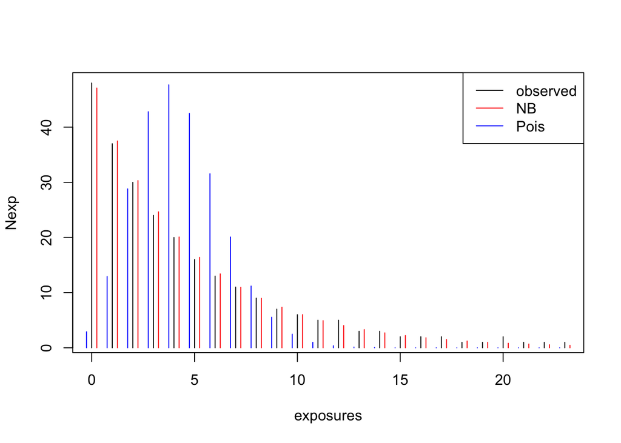

```r
plot(Nexp~exposures,type="h", data=BB.df)
lines((0:23)+.25, 250*dnbinom(0:23,mu=exp(coef(mod.nb)),size=mod.nb$theta),type="h", col="red")
lines((0:23)-.25,250*dpois(0:23,lambda=exp(coef(mod.poiss))), type="h", col="blue")
legend("topright", legend=c("observed", "NB","Pois"), col=c("black","red", "blue"), lty=rep(1,3))
```

This chart shows the shows the distribution of the observed data alongside the distribution of the Poisson and NB models. The plot shows that the NB model more closely resembles the observed data compared to the Poisson model. Our analysis also shows that the NB model is better suited for the data, from the chi squared test and the variance estimates.

## Median number of billboard exposures for commuters in this city

```r
median(y)
```

```
## [1] 3
```

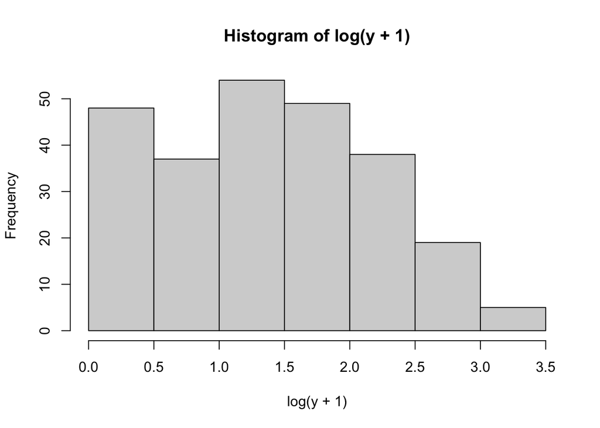

```r
hist(log(y+1))
```

```r
ci=confint(lm(log(y+1)~1)) # confint for mean of log(y+1)
exp(ci)-1  # back transform for the median
```

```
##                2.5 %   97.5 %
## (Intercept) 2.362321 3.197858
```

The median number of billboard exposures is expected to be between 2.4 and 3.2. The 95% CI for the mean for the log(y+1) data was calculated, then back transformed to obtain a 95% for the median value.

The initial model, that was considered was Poisson as we were modeling count data. However the mean and variance of the sample were not similar, so a Poisson model may not be appropriate. The chi-squared test confirmed this suspicion, which indicated the model was not a good fit. Next the NB distribution was considered. The chi-squared test revealed that this distribution was a better fit for the data, furthermore the expected variation of the model was closer to that of the sample.

## Executive summary

```r
exp(confint(mod.nb))
```

```
##    2.5 %   97.5 %
## 3.885801 5.131084
```

We wanted to find out how many billboards commuters are exposed to during their trip. We found that a NB model was adequate in explaining the number of people who were exposed to a certain amount of billboards.

We estimate that the mean number of billboard exposures is somewhere between 3.9 to 5.1. We estimate that the median number of exposures to be between 2.4 and 3.2.

# Futher analysis

## Paramaetric bootstrapping - simulation based on a fitted model

```r
BB.df <- read.csv('BB.csv')

# ungrouped data
y=rep(BB.df$exposures, rep(BB.df$Nexp))

# poisson model
mod.poiss=glm(y~1, family=poisson)
(poiss.dev <- deviance(mod.poiss))
```

```
## [1] 1203.288
```

```r
(poiss.df <- df.residual(mod.poiss))
```

```
## [1] 249
```

```r
# nb model
library(MASS)
mod.nb=glm.nb(y~1)
(nb.dev <- deviance(mod.nb))
```

```
## [1] 283.2723
```

```r
(nb.df <- df.residual(mod.nb))
```

```
## [1] 249
```

## Simulation for Poisson model

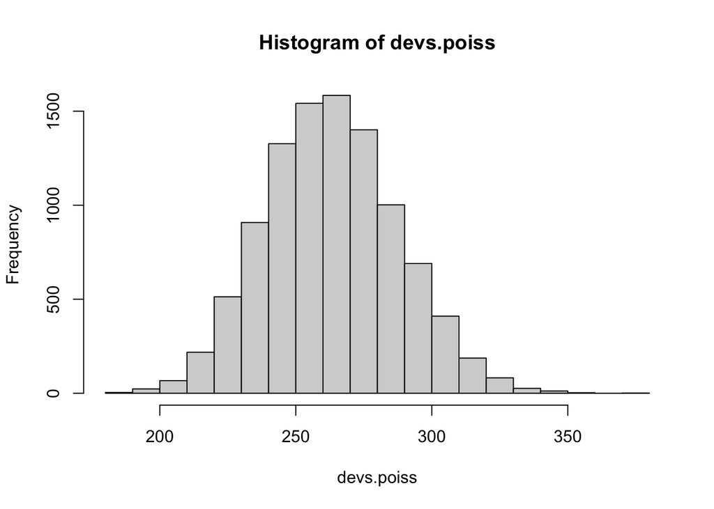

```r
devs.poiss=rep(0,10000)

for (i in 1:10000){
  ystar=rpois(250,mean(y))
  devs.poiss[i]=deviance(glm(ystar~1, family=poisson))
  }
hist(devs.poiss, freq=F, ylim=c(0,1.2*max(hist(devs.poiss)$density)))
```

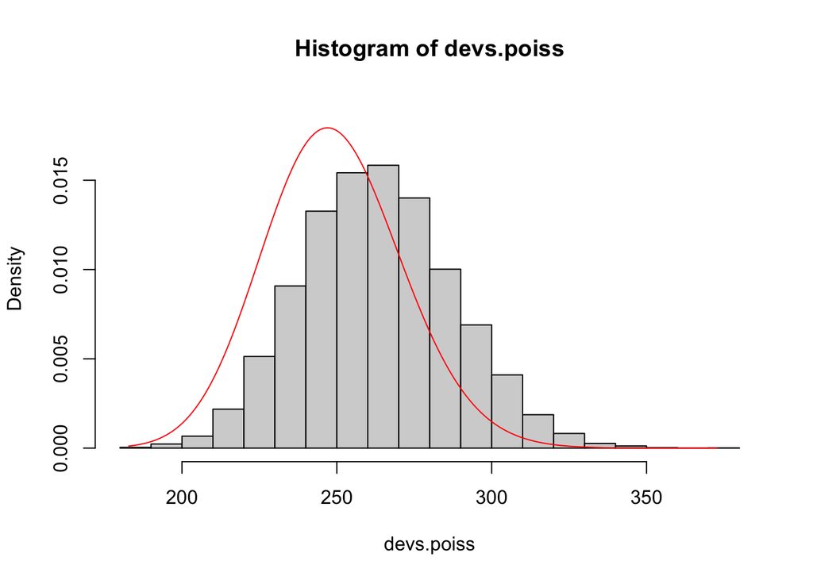

```r
# superimpose chi-squared distribution
xs=seq(min(devs.poiss), max(devs.poiss), length=1000)
lines(xs,dchisq(xs,df=mod.poiss$df.residual), col="red")
```

The deviances from the simulation are to the RHS of where theory says they should be, the distributions do not ‘line up’, a reason for this is that the Chi-square distribution for count data does not work well when there are low counts, for example the mean is ~4.5 in our sample which is < 5.

If we use a Chi-square approximation to calculate a p-value for a goodness of fit test for this data, we would reject the null hypothesis more than we should as the deviances are to the right of the Chi-square distribution with 249 degrees of freedom, this means that the Poisson model may be appropriate when the test reveals that it is not.

```r
round(pchisq(deviance(mod.poiss), df.residual(mod.poiss), lower.tail=F), 3)
```

```
## [1] 0
```

```r
round(mean(devs.poiss > deviance(mod.poiss)), 3)
```

```
## [1] 0
```

The p-value is similar to the Chi-square approximation which was ~0. The Poisson model is not a good fit.

# Simulation for NB model

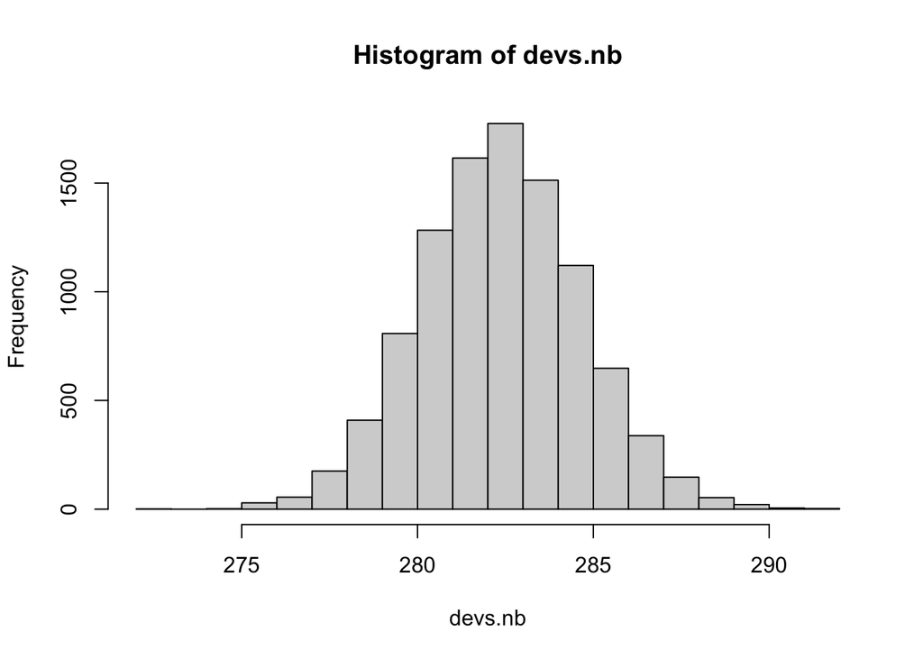

```r
devs.nb=rep(0,10000)

for (i in 1:10000){
  ystar=rnbinom(n=250,size=mod.nb$theta, mu=exp(coef(mod.nb)))
  devs.nb[i]=deviance(glm.nb(ystar~1))
  }
hist(devs.nb, freq=F, ylim=c(0,1.2*max(hist(devs.nb)$density)))
```

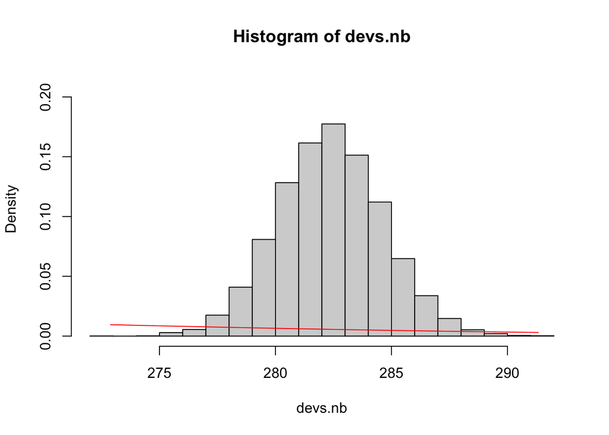

```r
# superimpose chi-squared distribution
xs=seq(min(devs.nb), max(devs.nb), length=1000)
lines(xs,dchisq(xs,df=mod.nb$df.residual), col="red")
```

The deviances are to the far right of the Chi-square distribution, and do not line up with the Chi-Square distribution with 249 degrees of freedom as there are quite a few low count values.

[figure not shown]

```r
hist(devs.nb, freq=F, xlim=c(200, max(devs.nb)), ylim=c(0,1.2*max(hist(devs.nb)$density)))
```

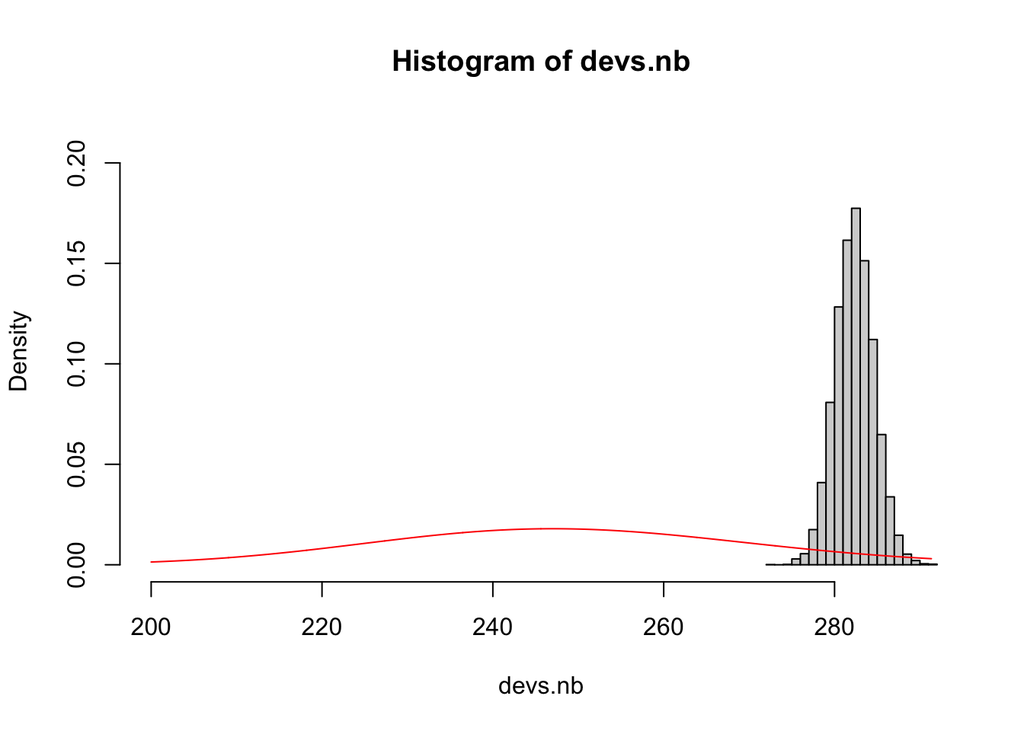

```r
xs=seq(200, max(devs.nb), length=1000)
lines(xs,dchisq(xs,df=mod.nb$df.residual), col="red")
```

Using the Chi-square test would not be a good idea as there will be many instances where the null hypothesis would be rejected when it should not be.

```r
round(pchisq(deviance(mod.nb), df.residual(mod.nb), lower.tail=F), 3)
```

```
## [1] 0.067
```

```r
#1- mean(devs.nb<deviance(mod.nb))
round(mean(devs.nb > deviance(mod.nb)), 3)
```

```
## [1] 0.345
```

The p-value is much higher than the Chi-square test, implying that the NB model is better than what the Chi-square test would have suggested.

## Non-parametric bootstrap to create a sampling distribution for the residual deviance

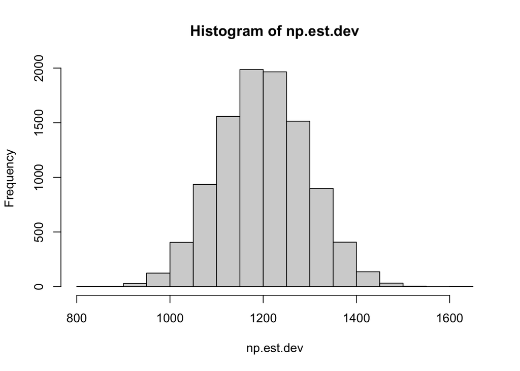

```r
# Number of observations
n = length(y)

## Setting the number of data sets and models to simulate.
n.sims <- 10000

## Creating vectors in which to store estimates.
np.est.dev <- numeric(n.sims)

for (i in 1:n.sims) { ## The for loop.
  ## Resampling from ungrouped data (y)
  samp = sample(1:n, replace=TRUE)
  y_samp <- y[samp]
  ## Fitting the model.
  fit <- glm(y_samp ~ 1, family = 'poisson')
  ## Extracting the model's deviance
  np.est.dev[i] <- deviance(fit)
}

hist(np.est.dev)
```

The histograms have a similar shape which is symmetrical, however they are centred around different values, ~260 for parametric and ~1200 for non-parametric. This is because for parametric we generate random counts based on the rate parameter of the sample and the Poisson model and then store the deviances per simulation, whereas in non-parametric bootstrapping the generated counts are from the sample itself with replacement. Hence the deviances could be different, in this case they are.